# Final Project - Practical Machine Learning

Miguel Pereira

April 30, 2016

This HTML describes the procedure followed to create an algorithm to determine if a person is performing a dumbell lift correctly using data from 6 subjects with accelerometers in 4 different locations. The data comes from this source: http://groupware.les.inf.puc-rio.br/har. (NOTE: The exploratory analysis of the dataset is ‘commented out’ to reduce the length of the HTML file)

```r
#Getting the training and testing datasets and checking the structure of the data provided.
training<-read.csv(url('https://d396qusza40orc.cloudfront.net/predmachlearn/pml-training.csv'),na.strings= c("NA",""," "))
testing<-read.csv(url('https://d396qusza40orc.cloudfront.net/predmachlearn/pml-testing.csv'),na.strings= c("NA",""," "))


#dim(training) #nrow (measurements)=19622   ncol(variables)=159
#training[1:10,1:10]
#names(training)

#dim(testing) #nrow (measurements)=20   ncol(variables)=159
#testing[1:10,1:10]

#Outcome variable
#summary(training$classe)
#class(training$classe) #It is a factor variable with 5 levels

#Cleaning the dataset
#1)Removing missing values
trainingNA <- apply(training, 2, function(x) {sum(is.na(x))})
trainingNoNA<-training[,which(trainingNA == 0)]
#dim(trainingNoNA)
#trainingNoNA[1:10,1:10]

testingNA <- apply(testing, 2, function(x) {sum(is.na(x))})
testingNoNA<-testing[,which(testingNA == 0)]

#2)Removing identifier columns
trainingClean<-trainingNoNA[,8:ncol(trainingNoNA)]
#dim(trainingClean)
#trainingClean[1:10,1:10]

testingClean<-testingNoNA[,8:ncol(testingNoNA)]
test<-testingClean
#dim(test)
#test[1:10,1:10]
```

Classe=A corresponds to the correct exercise whereas the other classes’s correspond to common mistakes according to the supporting information in the website provided (http://groupware.les.inf.puc-rio.br/har).

# Cross-Validation

To be have a better idea of what the test set accuracy is, the training dataset will be sub-split in two, a training and a cross-validation set, in a 70/30 ratio:

```r
library(caret)
set.seed(123) #to ensure reproducibility

inTrain <- createDataPartition(y = trainingClean$classe, p = 0.7, list = FALSE)
train <- trainingClean[inTrain, ]
crossVal <- trainingClean[-inTrain, ]
```

# Building a model

The dataset is composed of many variables and therefore we can consider summarizing these using principal component anaylsis. First, we will check the correlation between the variables by means of a correlation plot.

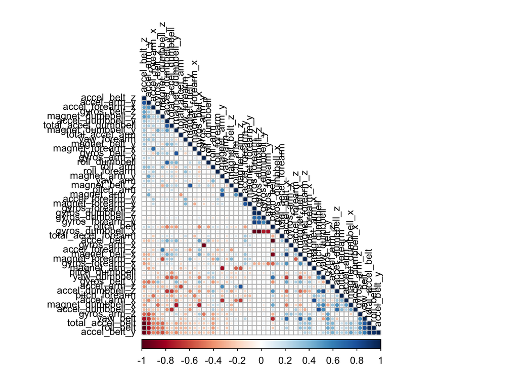

```r
# plotting a correlation matrix
#install.packages('corrplot')
library(corrplot)
M <- abs(cor(train[,-ncol(train)]))
M2 <- cor(train[,-ncol(train)])
corrplot(M2, order = "FPC", method = "circle", type = "lower", tl.cex = 0.8,  tl.col = rgb(0, 0, 0))
```

```r
diag(M)<-0
length(which(M>0.8))
```

```
## [1] 38
```

The variables are relatively correlated with each other. Thefore, we can summarize the data as follows, thus getting only 12 predictors as opposed to 52:

```r
#Principal component analysis
trainPca<-preProcess(train[,-ncol(train)],method='pca',thresh=0.8)
trainPC<-predict(trainPca,train[,-ncol(train)])
```

We selected a random forest model to predict the classification because it has methods for balancing error in class population unbalanced data sets. The correlation between any two trees in the forest increases the forest error rate. In this case, we will fit a random forest model with all the variables and with the principal components only provided that including all the variables is not computationally too demanding:

```r
#Random forest model - all variables
library(randomForest)
set.seed(124)
modFit<-randomForest(classe~.,data=train)
predCrossVal<-predict(modFit,crossVal)
modFit
```

```
##
## Call:
##  randomForest(formula = classe ~ ., data = train)
##                Type of random forest: classification
##                      Number of trees: 500
## No. of variables tried at each split: 7
##
##         OOB estimate of  error rate: 0.55%
## Confusion matrix:
##      A    B    C    D    E class.error
## A 3901    3    0    1    1 0.001280082
## B   10 2644    4    0    0 0.005267118
## C    0   19 2373    4    0 0.009599332
## D    0    0   26 2225    1 0.011989343
## E    0    0    3    4 2518 0.002772277
```

```r
#Accuracy
confusionMatrix(crossVal$classe,predCrossVal)
```

```
## Confusion Matrix and Statistics
##
##           Reference
## Prediction    A    B    C    D    E
##          A 1673    1    0    0    0
##          B    5 1133    1    0    0
##          C    0   12 1014    0    0
##          D    0    0   13  950    1
##          E    0    0    0    0 1082
##
## Overall Statistics
##
##                Accuracy : 0.9944
##                  95% CI : (0.9921, 0.9961)
##     No Information Rate : 0.2851
##     P-Value [Acc > NIR] : < 2.2e-16
##
##                   Kappa : 0.9929
##  Mcnemar's Test P-Value : NA
##
## Statistics by Class:
##
##                      Class: A Class: B Class: C Class: D Class: E
## Sensitivity            0.9970   0.9887   0.9864   1.0000   0.9991
## Specificity            0.9998   0.9987   0.9975   0.9972   1.0000
## Pos Pred Value         0.9994   0.9947   0.9883   0.9855   1.0000
## Neg Pred Value         0.9988   0.9973   0.9971   1.0000   0.9998
## Prevalence             0.2851   0.1947   0.1747   0.1614   0.1840
## Detection Rate         0.2843   0.1925   0.1723   0.1614   0.1839
## Detection Prevalence   0.2845   0.1935   0.1743   0.1638   0.1839
## Balanced Accuracy      0.9984   0.9937   0.9920   0.9986   0.9995
```

```r
#Random forest model - only PCs
set.seed(125)
modFitPC<-randomForest(train$classe~.,data=trainPC)
crossValPC<-predict(trainPca,crossVal[,-ncol(crossVal)])
modFitPC
```

```
##
## Call:
##  randomForest(formula = train$classe ~ ., data = trainPC)
##                Type of random forest: classification
##                      Number of trees: 500
## No. of variables tried at each split: 3
##
##         OOB estimate of  error rate: 4.08%
## Confusion matrix:
##      A    B    C    D    E class.error
## A 3817   24   37   21    7  0.02278546
## B   73 2503   57   14   11  0.05831452
## C   16   37 2296   37   10  0.04173623
## D   19   11  109 2104    9  0.06571936
## E    4   21   19   25 2456  0.02732673
```

```r
predCrossValPC<-predict(modFitPC,crossValPC)

#Accuracy
confusionMatrix(crossVal$classe,predCrossValPC)
```

```
## Confusion Matrix and Statistics
##
##           Reference
## Prediction    A    B    C    D    E
##          A 1626   13   13   14    8
##          B   30 1075   20    8    6
##          C    8   19  973   15   11
##          D   10    6   50  896    2
##          E    4   13   10    5 1050
##
## Overall Statistics
##
##                Accuracy : 0.955
##                  95% CI : (0.9494, 0.9601)
##     No Information Rate : 0.2851
##     P-Value [Acc > NIR] : < 2.2e-16
##
##                   Kappa : 0.943
##  Mcnemar's Test P-Value : 0.0002744
##
## Statistics by Class:
##
##                      Class: A Class: B Class: C Class: D Class: E
## Sensitivity            0.9690   0.9547   0.9128   0.9552   0.9749
## Specificity            0.9886   0.9866   0.9890   0.9863   0.9933
## Pos Pred Value         0.9713   0.9438   0.9483   0.9295   0.9704
## Neg Pred Value         0.9877   0.9893   0.9809   0.9915   0.9944
## Prevalence             0.2851   0.1913   0.1811   0.1594   0.1830
## Detection Rate         0.2763   0.1827   0.1653   0.1523   0.1784
## Detection Prevalence   0.2845   0.1935   0.1743   0.1638   0.1839
## Balanced Accuracy      0.9788   0.9706   0.9509   0.9707   0.9841
```

# Making predictions

Using the testing dataset with 20 observations that was loaded in the begining, we can fit the model and see how well it works in this testing dataset.

```r
pred<-predict(modFit,test)
pred
```

```
##  1  2  3  4  5  6  7  8  9 10 11 12 13 14 15 16 17 18 19 20
##  B  A  B  A  A  E  D  B  A  A  B  C  B  A  E  E  A  B  B  B
## Levels: A B C D E
```